# Targets pipeline

### The Coursera Solution Pipeline[^1]

Full documentation for the rationale behind this implementation is in the ENDGAME.Rmd file.

The diagram for the pipeline which will allow iteration from cleaning and onwards is [here](https://docs.google.com/drawings/d/1ulZlV0PZG9nbkvX4l6Qm6_dJ9GT1m37ahK7CU9PbaNE/edit?usp=sharing) :

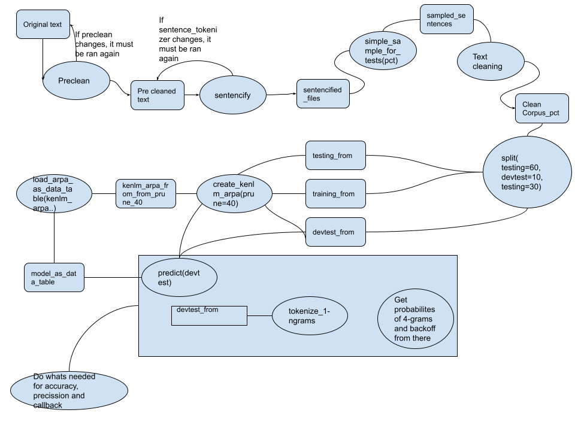

### Implementing the pipeline

#### Setup

Basic startup setup

```r
library(targets)
tar_unscript()
package_list <-
  c(
    "dplyr",
    "ggplot2",
    "readr",
    "tidyr",
    "data.table",
    "progressr",
    "R6",
    "pins",
    "rsample",
    "tidytext",
    "purrr",
    "furrr",
    "magrittr",
    "stringr",
    "dtplyr",
    "targets",
    "tarchetypes"
  )
xfun::pkg_attach2(package_list)
package_list <-
  c(
    "dplyr",
    "ggplot2",
    "readr",
    "tidyr",
    "data.table",
    "progressr",
    "R6",
    "pins",
    "rsample",
    "tidytext",
    "purrr",
    "furrr",
    "magrittr",
    "stringr",
    "dtplyr",
    "futile.logger",
     "tarchetypes"
  )
# options(tidyverse.quiet = TRUE)
targets::tar_option_set(format = 'qs')
targets::tar_option_set(packages = package_list)
library(targets)
xfun::pkg_attach(package_list)
source("R/global_variables.R")
options(datatable.verbose = FALSE)
```

```
#> Establish _targets.R and _targets_r/globals/t-globals.R.
```

#### Building an iteration friendly environment

As is evident from the pipeline, text comes with nulls and all sorts of nasty. This requires a precleaning step:

```r
source("R/preclean_functions.R")

  tar_target(preclean,
             preclean_files(
               list.files(en_data_dir, pattern = '*.txt')
             ))
```

```
#> Establish _targets.R and _targets_r/targets/preclean-target.R.
```

```r
tar_make()
```

```
#>
#>
#>
#>
#>
#>
#> ✔ skip target preclean
#> ✔ skip pipeline: 0.044 seconds
```

After that and crucially prior to sampling, we “sentencify”, that is, we split the text into sentences:

```r
source("R/sentencify.R")

  tar_target(
    sentenced_files,
    sentencify(precleaned_files = preclean),
    format = "file"
  )
```

```
#> Establish _targets.R and _targets_r/targets/sentencify-target.R.
```

```r
tar_make()
```

```
#>
#>
#>
#>
#>
#>
#> ✔ skip target preclean
#> ✔ skip target sentenced_files
#> ✔ skip pipeline: 0.062 seconds
```

Now here comes an interesting part. I do a quick sample of sentences of the whole corpus. Only loading 1% of it:

```r
source("R/simple_sample.R")
source("R/load_text_as_table.R")

tar_target(sample_one_pct,
           simple_sample(sentenced_files,pct = 0.01),
           format = "file")
```

```
#> Establish _targets.R and _targets_r/targets/sample-one-pct-target.R.
```

```r
tar_make()
```

```
#>
#>
#>
#>
#>
#>
#> ✔ skip target preclean
#> ✔ skip target sentenced_files
#> ✔ skip target sample_one_pct
#> ✔ skip pipeline: 0.085 seconds
```

Having sampled, we can now split in training and testing set:

```r
source("R/create_our_splits.R")
tar_target(splits_of_onepct,
           create_our_splits(sample_one_pct))
```

```
#> Establish _targets.R and _targets_r/targets/splits_of_onepct.R.
```

And from that, a subsplit of training and the final training set, given back as lists. Those need to be extracted into separate targets just for clean tar_target() code down the pipeline:

```r
source("R/create_training_and_devset.R")

list(
  tar_target(
    testing_onepct,
    splits_of_onepct %>%
      rsample::testing()
    ),
    tar_target(pre_training_onepct,
               splits_of_onepct %>%
                 rsample::training()
               ),
    tar_target(
      training_devtest_split_onepct,
      create_training_and_devset(pre_training_onepct)
    ),
    tar_target(training_onepct,
               purrr::pluck(training_devtest_split_onepct, "training")
               ),
    tar_target(devtest_onepct,
               purrr::pluck(training_devtest_split_onepct, "devtest")
               )

  )
```

```
#> Establish _targets.R and _targets_r/targets/training-devtest-testing.R.
```

Ok, now we are cleaning the text by sentence so we can later down the line finally build models and then evaluate them.

We will try to do this in parallel as per https://books.ropensci.org/targets/hpc.html#future-locally, so first we run all those above sequentially:

```r
tar_make()
```

```
#>
#>
#>
#>
#>
#>
#> ✔ skip target preclean
#> ✔ skip target sentenced_files
#> ✔ skip target sample_one_pct
#> • start target splits_of_onepct
#> • built target splits_of_onepct
#> • start target pre_training_onepct
#> • built target pre_training_onepct
#> • start target testing_onepct
#> • built target testing_onepct
#> • start target training_devtest_split_onepct
#> • built target training_devtest_split_onepct
#> • start target devtest_onepct
#> • built target devtest_onepct
#> • start target training_onepct
#> • built target training_onepct
#> • end pipeline: 2.401 seconds
```

And now we build the parallel cleaning targets:

```r
source("R/clean_texts.R")
list(
  tar_target(
    clean_testing_onepct,
    clean_texts_dt(testing_onepct)
  ),
  tar_target(
    clean_training_onepct,
    clean_texts_dt(training_onepct)
  ),
  tar_target(
    clean_devtest_onepct,
    clean_texts_dt(devtest_onepct)
  )

)
```

```
#> Establish _targets.R and _targets_r/targets/cleaning-target.R.
```

And build those…

```r
library(future)
library(future.callr)
plan(callr)
tar_make_future(workers = 6)
```

```
#>
#>
#>
#>
#>
#>
#> ✔ skip target preclean
#> ✔ skip target sentenced_files
#> ✔ skip target sample_one_pct
#> ✔ skip target splits_of_onepct
#> ✔ skip target testing_onepct
#> • start target clean_testing_onepct
#> ✔ skip target pre_training_onepct
#> ✔ skip target training_devtest_split_onepct
#> ✔ skip target training_onepct
#> • start target clean_training_onepct
#> ✔ skip target devtest_onepct
#> • start target clean_devtest_onepct
#> • built target clean_devtest_onepct
#> • built target clean_testing_onepct
#> • built target clean_training_onepct
#> • end pipeline: 2.058 minutes
```

Now we have all we need toooo….

#### Building models

We build the model exclusively on the training set. This is how to do that:

```r
source("R/kenlm_functions.R")

# KenLM requires a simple clean text file to build.
# So we do that with our training set

  tar_target(training_as_file_onepct,
             create_file_from_data_table_set(
               clean_training_onepct,
               'training_corpus_onepct.txt'
             ),
             format="file")
```

```
#> Establish _targets.R and _targets_r/targets/training-file-as-onepct-target.R.
```

```r
tar_target(kenlm_arpafile_onepct,
             create_kenlm_arpa(
               source_file = tar_read(training_as_file_onepct),
               outfile = 'kenlm_model_onepct'
                               ),

             format='file')
```

```
#> Establish _targets.R and _targets_r/targets/kenlm-arpafile-onepct-target.R.
```

```r
  tar_target(kenlm_model_onepct,
          load_arpa_as_data_table(
            source_file = kenlm_arpafile_onepct
              ))
```

```
#> Establish _targets.R and _targets_r/targets/kenlm-model-onepct-target.R.
```

And then make those…

```r
 tar_make()
```

```
#>
#>
#>
#>
#>
#>
#> ✔ skip target preclean
#> ✔ skip target sentenced_files
#> ✔ skip target sample_one_pct
#> ✔ skip target splits_of_onepct
#> ✔ skip target testing_onepct
#> ✔ skip target pre_training_onepct
#> ✔ skip target clean_testing_onepct
#> ✔ skip target training_devtest_split_onepct
#> ✔ skip target training_onepct
#> ✔ skip target devtest_onepct
#> ✔ skip target clean_training_onepct
#> ✔ skip target clean_devtest_onepct
#> • start target training_as_file_onepct
#> • built target training_as_file_onepct
#> • start target kenlm_arpafile_onepct
#> === 1/5 Counting and sorting n-grams ===
#> Reading /mnt/BIGSEAGATE/DEVEL_NOSYNC/OAS_PROJECTS/capstone raw data/final/en_US/clean/training_corpus_onepct.txt
#> ----5---10---15---20---25---30---35---40---45---50---55---60---65---70---75---80---85---90---95--100
#> Unigram tokens 1358792 types 140453
#> === 2/5 Calculating and sorting adjusted counts ===
#> Chain sizes: 1:1685436 2:3255847168 3:6104713728 4:9767541760 5:14244332544
#> Statistics:
#> 1 3021/140453 D1=0.732019 D2=1.02402 D3+=1.31274
#> 2 2489/687751 D1=0.843673 D2=1.10231 D3+=1.25065
#> 3 485/1104522 D1=0.925113 D2=1.20079 D3+=1.35852
#> 4 57/1185524 D1=0.972515 D2=1.35347 D3+=1.41318
#> 5 3/1127854 D1=0.984198 D2=1.64867 D3+=1.70864
#> Memory estimate for binary LM:
#> type     kB
#> probing 147 assuming -p 1.5
#> probing 177 assuming -r models -p 1.5
#> trie    101 without quantization
#> trie     91 assuming -q 8 -b 8 quantization
#> trie    100 assuming -a 22 array pointer compression
#> trie     89 assuming -a 22 -q 8 -b 8 array pointer compression and quantization
#> === 3/5 Calculating and sorting initial probabilities ===
#> Chain sizes: 1:36252 2:39824 3:9700 4:1368 5:84
#> === 4/5 Calculating and writing order-interpolated probabilities ===
#> Chain sizes: 1:36252 2:39824 3:9700 4:1368 5:84
#> === 5/5 Writing ARPA model ===
#> Name:lmplz   VmPeak:32764160 kB  VmRSS:8748 kB   RSSMax:5811168 kB   user:3.5267 sys:7.92767 CPU:11.4544 real:8.24867
#> • built target kenlm_arpafile_onepct
#> • start target kenlm_model_onepct
#> Column 7 ['backoff'] of item 5 appears in position 4 in item 4. Set use.names=TRUE to match by column name, or use.names=FALSE to ignore column names. use.names='check' (default from v1.12.2) emits this message and proceeds as if use.names=FALSE for  backwards compatibility. See news item 5 in v1…
#> • built target kenlm_model_onepct
#> • end pipeline: 9.601 seconds
```

Now, modeling actually has a cutoff value, that is, a lot of monograms are not even allowed to be in the model. Additionally, it is just plain normal that the test and devtest sets have words that are unks.

Unks are not only hard to search for but also have to be replaced throughout all texts. This means its better to preprocess them.

```r
source('./R/model_functions.R')
tar_target(ngramified_devtest_onepct,
tar_read(clean_devtest_onepct) %>%
    n_gramify_all(text_dt = .,
                        model_dt = tar_read(kenlm_model_onepct))

)
```

```
#> Establish _targets.R and _targets_r/targets/ngramified-devtest-onepct-target.R.
```

```r
tar_make()
```

```
#>
#>
#>
#>
#>
#>
#> ✔ skip target preclean
#> ✔ skip target sentenced_files
#> ✔ skip target sample_one_pct
#> ✔ skip target splits_of_onepct
#> ✔ skip target testing_onepct
#> ✔ skip target pre_training_onepct
#> ✔ skip target clean_testing_onepct
#> ✔ skip target training_devtest_split_onepct
#> ✔ skip target training_onepct
#> ✔ skip target devtest_onepct
#> ✔ skip target clean_training_onepct
#> ✔ skip target clean_devtest_onepct
#> ✔ skip target training_as_file_onepct
#> ✔ skip target kenlm_arpafile_onepct
#> ✔ skip target kenlm_model_onepct
#> • start target ngramified_devtest_onepct
#> • built target ngramified_devtest_onepct
#> • end pipeline: 34.98 seconds
```

Unkified:

```r
source('./R/model_functions.R')
tar_target(
  unkified_devtest_onepct,
  tar_read(ngramified_devtest_onepct) %>%
    unkify_all(
      unked_text_dt = .,
      model_dt = tar_read(kenlm_model_onepct)
    )

)
```

```
#> Establish _targets.R and _targets_r/targets/unkified-devtest-onepct-target.R.
```

```r
tar_make()
```

```
#>
#>
#>
#>
#>
#>
#> ✔ skip target preclean
#> ✔ skip target sentenced_files
#> ✔ skip target sample_one_pct
#> ✔ skip target splits_of_onepct
#> ✔ skip target testing_onepct
#> ✔ skip target pre_training_onepct
#> ✔ skip target clean_testing_onepct
#> ✔ skip target training_devtest_split_onepct
#> ✔ skip target training_onepct
#> ✔ skip target devtest_onepct
#> ✔ skip target clean_training_onepct
#> ✔ skip target clean_devtest_onepct
#> ✔ skip target training_as_file_onepct
#> ✔ skip target kenlm_arpafile_onepct
#> ✔ skip target kenlm_model_onepct
#> ✔ skip target ngramified_devtest_onepct
#> • start target unkified_devtest_onepct
#> • built target unkified_devtest_onepct
#> • end pipeline: 23.276 seconds
```

#### Model evaluation

So now we can actually evaluate the devtest:

```r
source('./R/model_functions.R')

tar_target(
  devtest_onepct_sentences_probs,
  tar_read(unkified_devtest_onepct) %>%
    corpus_probabilities_by_sentence(model_dt = tar_read(kenlm_model_onepct))
)
```

```
#> Establish _targets.R and _targets_r/targets/sentenced-devtest-onepct-target.R.
```

```r
tar_make()
```

```
#>
#>
#>
#>
#>
#>
#> ✔ skip target preclean
#> ✔ skip target sentenced_files
#> ✔ skip target sample_one_pct
#> ✔ skip target splits_of_onepct
#> ✔ skip target testing_onepct
#> ✔ skip target pre_training_onepct
#> ✔ skip target clean_testing_onepct
#> ✔ skip target training_devtest_split_onepct
#> ✔ skip target training_onepct
#> ✔ skip target devtest_onepct
#> ✔ skip target clean_training_onepct
#> ✔ skip target clean_devtest_onepct
#> ✔ skip target training_as_file_onepct
#> ✔ skip target kenlm_arpafile_onepct
#> ✔ skip target kenlm_model_onepct
#> ✔ skip target ngramified_devtest_onepct
#> ✔ skip target unkified_devtest_onepct
#> • start target devtest_onepct_sentences_probs
#> • built target devtest_onepct_sentences_probs
#> • end pipeline: 24.217 seconds
```

As for the evaluation, we now have one model and one devtest and the probability of that devtest with backoff values and not. This can be seen here, as we evaluate the held-out devset:

```r
source('R/model_functions.R')
tar_read(devtest_onepct_sentences_probs) %>%
  corpus_probability()
```

```
#>    probability  backoff     total
#> 1:   -425756.9 52691.05 -373065.8
```

```r
source('./R/model_functions.R')
  tar_target(
    ngramified_training_onepct,
    tar_read(clean_training_onepct) %>%
      n_gramify_all(text_dt = .,
                    model_dt = tar_read(kenlm_model_onepct))

  )
```

```
#> Establish _targets.R and _targets_r/targets/ngramified-training-onepct-target.R.
```

```r
tar_make()
```

```
#>
#>
#>
#>
#>
#>
#> ✔ skip target preclean
#> ✔ skip target sentenced_files
#> ✔ skip target sample_one_pct
#> ✔ skip target splits_of_onepct
#> ✔ skip target testing_onepct
#> ✔ skip target pre_training_onepct
#> ✔ skip target clean_testing_onepct
#> ✔ skip target training_devtest_split_onepct
#> ✔ skip target training_onepct
#> ✔ skip target devtest_onepct
#> ✔ skip target clean_training_onepct
#> ✔ skip target clean_devtest_onepct
#> ✔ skip target training_as_file_onepct
#> ✔ skip target kenlm_arpafile_onepct
#> ✔ skip target kenlm_model_onepct
#> • start target ngramified_training_onepct
#> • built target ngramified_training_onepct
#> ✔ skip target ngramified_devtest_onepct
#> ✔ skip target unkified_devtest_onepct
#> ✔ skip target devtest_onepct_sentences_probs
#> • end pipeline: 5.075 minutes
```

```r
tar_target(
    unkified_training_onepct,
    tar_read(ngramified_training_onepct) %>%
      unkify_all(
        unked_text_dt = .,
        model_dt = tar_read(kenlm_model_onepct)
      )

  )
```

```
#> Establish _targets.R and _targets_r/targets/ngramified-unkified-training-onepct-target.R.
```

```r
tar_make()
```

```
#>
#>
#>
#>
#>
#>
#> ✔ skip target preclean
#> ✔ skip target sentenced_files
#> ✔ skip target sample_one_pct
#> ✔ skip target splits_of_onepct
#> ✔ skip target testing_onepct
#> ✔ skip target pre_training_onepct
#> ✔ skip target clean_testing_onepct
#> ✔ skip target training_devtest_split_onepct
#> ✔ skip target training_onepct
#> ✔ skip target devtest_onepct
#> ✔ skip target clean_training_onepct
#> ✔ skip target clean_devtest_onepct
#> ✔ skip target training_as_file_onepct
#> ✔ skip target kenlm_arpafile_onepct
#> ✔ skip target kenlm_model_onepct
#> ✔ skip target ngramified_training_onepct
#> ✔ skip target ngramified_devtest_onepct
#> • start target unkified_training_onepct
#> • built target unkified_training_onepct
#> ✔ skip target unkified_devtest_onepct
#> ✔ skip target devtest_onepct_sentences_probs
#> • end pipeline: 3.323 minutes
```

```r
tar_target(
    training_onepct_sentences_probs,
    tar_read(unkified_training_onepct) %>%
      corpus_probabilities_by_sentence(model_dt = tar_read(kenlm_model_onepct))
  )
```

```
#> Establish _targets.R and _targets_r/targets/training-sentences-probs-target.R.
```

```r
tar_make()
```

```
#>
#>
#>
#>
#>
#>
#> ✔ skip target preclean
#> ✔ skip target sentenced_files
#> ✔ skip target sample_one_pct
#> ✔ skip target splits_of_onepct
#> ✔ skip target testing_onepct
#> ✔ skip target pre_training_onepct
#> ✔ skip target clean_testing_onepct
#> ✔ skip target training_devtest_split_onepct
#> ✔ skip target training_onepct
#> ✔ skip target devtest_onepct
#> ✔ skip target clean_training_onepct
#> ✔ skip target clean_devtest_onepct
#> ✔ skip target training_as_file_onepct
#> ✔ skip target kenlm_arpafile_onepct
#> ✔ skip target kenlm_model_onepct
#> ✔ skip target ngramified_training_onepct
#> ✔ skip target ngramified_devtest_onepct
#> ✔ skip target unkified_training_onepct
#> ✔ skip target unkified_devtest_onepct
#> • start target training_onepct_sentences_probs
#> • built target training_onepct_sentences_probs
#> ✔ skip target devtest_onepct_sentences_probs
#> • end pipeline: 3.441 minutes
```

##### Probability of corpuses

The probablity of a corpus is given by the straight sum of the log odds of each sentence. What follows is the training and devtest densities of the total probability (log odds + backoff)

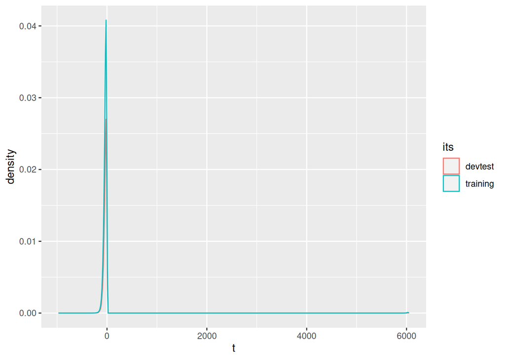

```r
 list(
     tar_read(training_onepct_sentences_probs) %>% .[,its:="training"],
     tar_read(devtest_onepct_sentences_probs) %>% .[,its:="devtest"]) %>%
     rbindlist() %>%
     ggplot(aes(x=t,color=its))+
     geom_density()
```

Bearing in mind that this kenlm model is built with 40 as cutoff value, that does not look too crazy, but it does not look too efficient.

And this is what this pretty pipeline, from precleaning to generating a model, looks like:

```r
tar_visnetwork()
```

[interactive chart not shown]

This is some sort of childish because kenlm is really much more efficient in evaluating and calculating perplexity on whole corpuses. So we have another way to construct the pipeline that takes advantage of this fact.

Here it goes.

### The KenLM way

In the kenLM way, we might preserve the strategy all the way to splits. It is the way we unkify, model and evaluate a corpus where things change.

At the end of this branch of the pipeline, we will have targets that compare corpuses lowercased to normal, different cutoff values, and different end model sizes.

So, first we build two full versions of the raw corpus both lower and upper case:

```r
tarchetypes::tar_map(
    values=tibble(to_lower=c(TRUE,FALSE)),
    tar_target(
        preclean_lowercase,
        preclean_files(files = list.files(en_data_dir, pattern = '*.txt'),
                       to_lower = to_lower)
    ),
    tar_target(sentencified_lowercase,
               sentencify(preclean_lowercase),
                format = "file")
) %>% list()
```

```
#> Establish _targets.R and _targets_r/targets/kenlm-pipeline-target.R.
```

```r
tar_visnetwork()
```

[interactive chart not shown]

```r
tar_manifest()
```

```
#>
#>
#>
#>
#>
#>
#> # A tibble: 25 × 3
#>    name                         command                                  pattern
#>    <chr>                        <chr>                                    <chr>
#>  1 preclean_lowercase_TRUE      "preclean_files(files = list.files(en_d… <NA>
#>  2 preclean_lowercase_FALSE     "preclean_files(files = list.files(en_d… <NA>
#>  3 preclean                     "preclean_files(list.files(en_data_dir,… <NA>
#>  4 sentencified_lowercase_TRUE  "sentencify(preclean_lowercase_TRUE)"    <NA>
#>  5 sentencified_lowercase_FALSE "sentencify(preclean_lowercase_FALSE)"   <NA>
#>  6 sentenced_files              "sentencify(precleaned_files = preclean… <NA>
#>  7 sample_one_pct               "simple_sample(sentenced_files, pct = 0… <NA>
#>  8 splits_of_onepct             "create_our_splits(sample_one_pct)"      <NA>
#>  9 testing_onepct               "splits_of_onepct %>% rsample::testing(… <NA>
#> 10 pre_training_onepct          "splits_of_onepct %>% rsample::training… <NA>
#> # … with 15 more rows
```

#### Tunning

Ok, of to the subject of more close up analisys of this thing, we must see really what differs. For one, I want to see how does cutoff value change, and what happens if we deal with lowercase only data.

```r
expand.grid(
    to_lower=c(TRUE,FALSE),
    kenlm_cutoff=c(10,20,30)
)
```

```
#>   to_lower kenlm_cutoff
#> 1     TRUE           10
#> 2    FALSE           10
#> 3     TRUE           20
#> 4    FALSE           20
#> 5     TRUE           30
#> 6    FALSE           30
```

[^1]: For reference the oficial manual is: https://books.ropensci.org/targets/markdown.html#target-markdown